# Grapevine

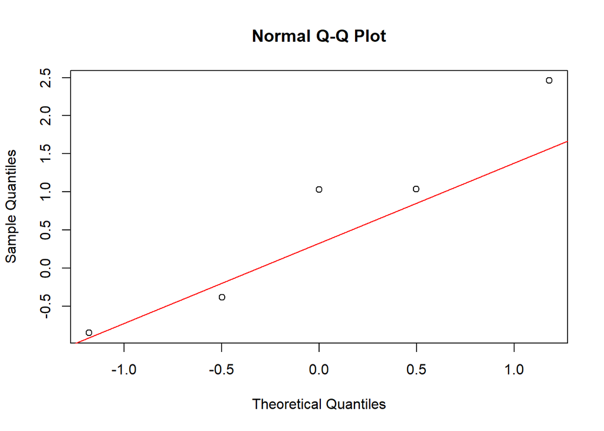

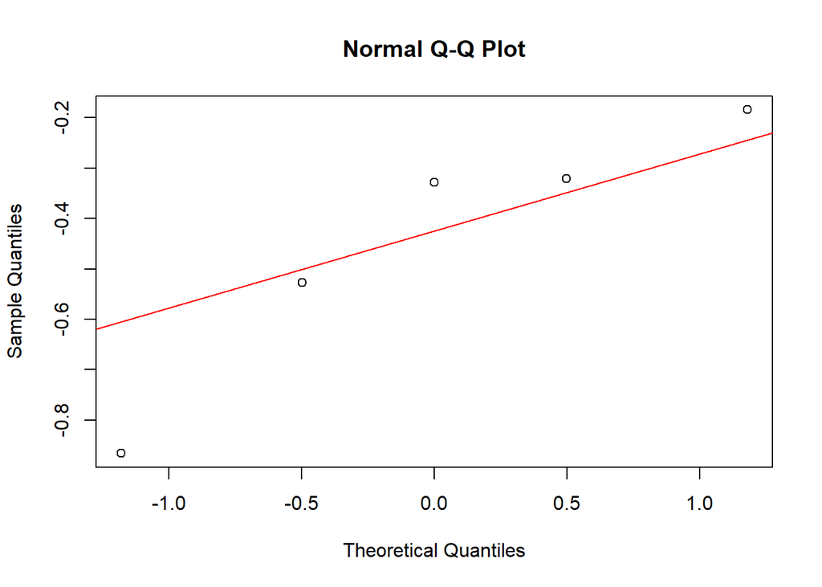

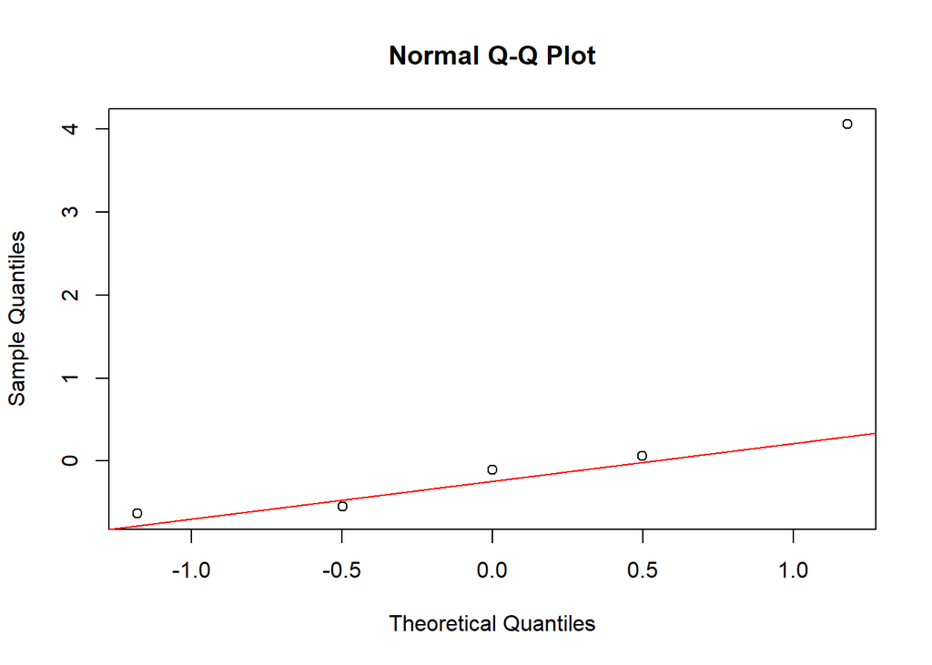

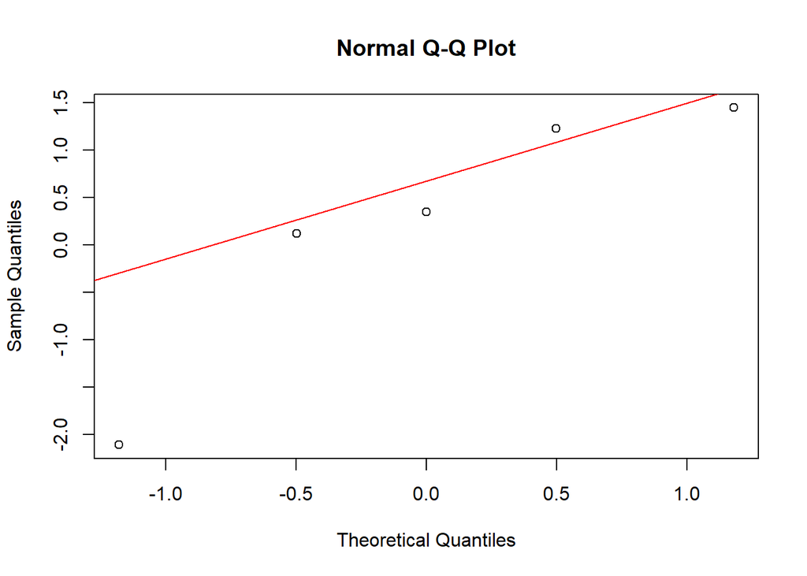

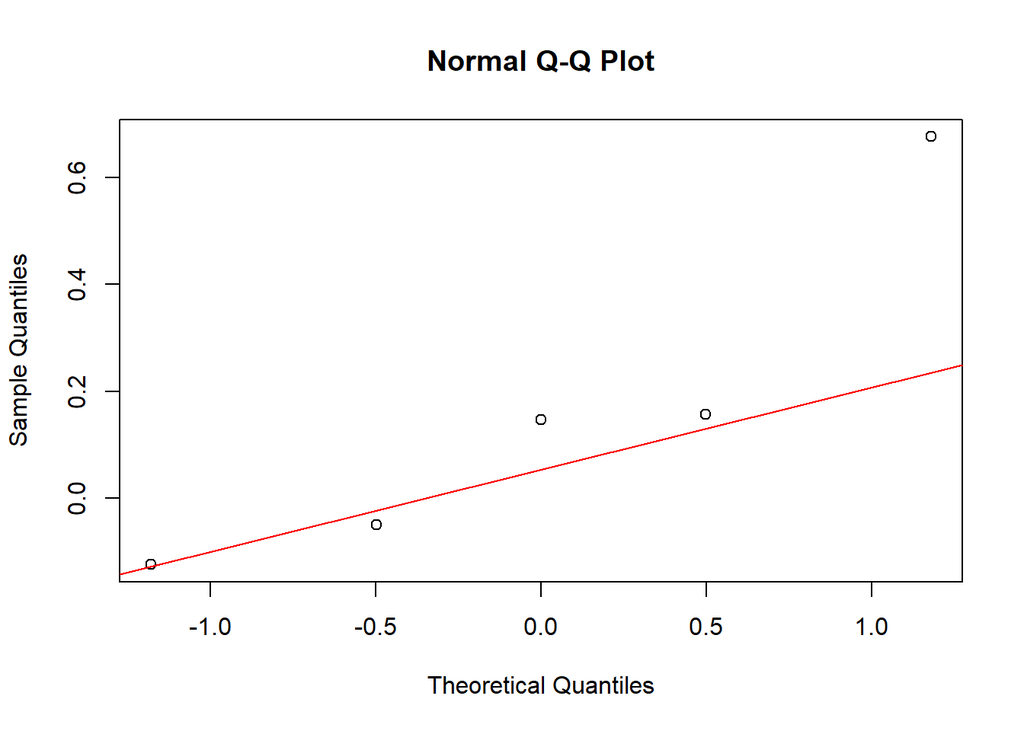

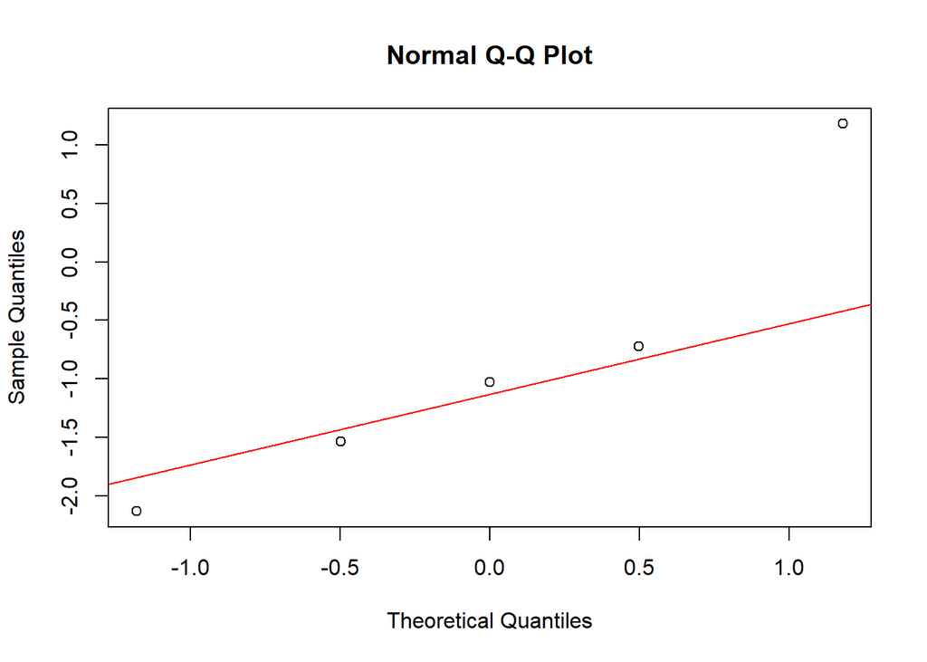

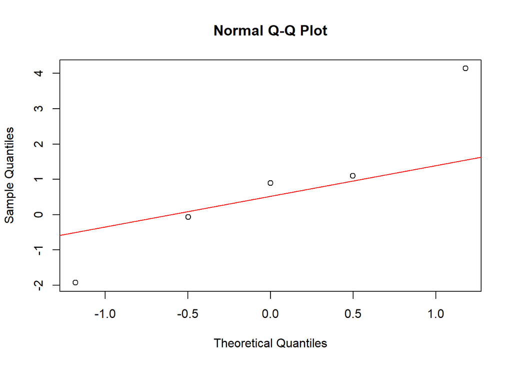

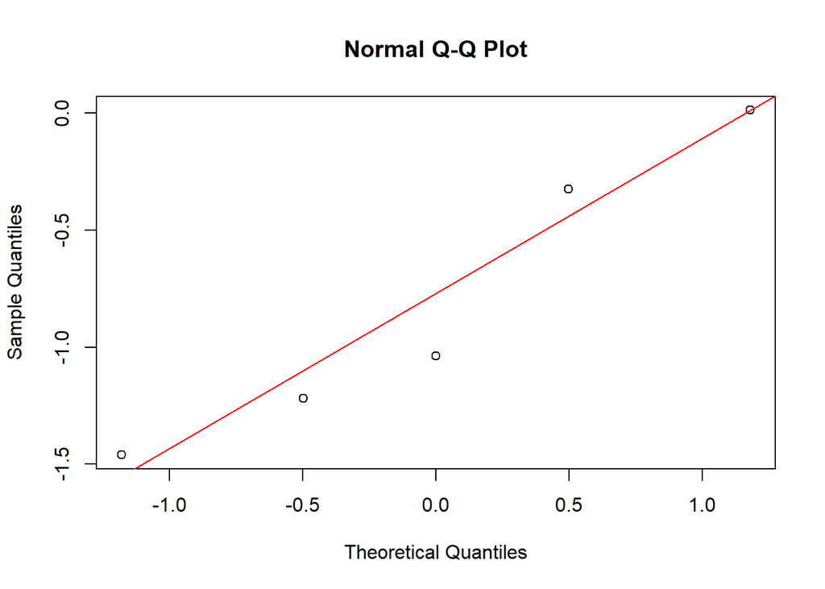

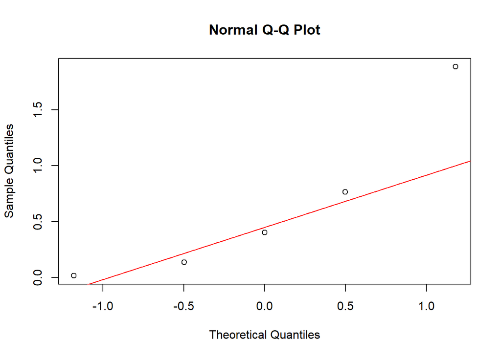

F test and randomization test for equal variance between treatments for each block in merlot 2020

```
## [1] "F test"
## [1] 0.2494025
## [1] "rand test"
## [1] 0.4722222
## [1] "F test"
## [1] 0.5232279
## [1] "rand test"
## [1] 0.5119048
## [1] "F test"
## [1] 0.001876501
## [1] "rand test"
## [1] 0.6706349
## [1] "F test"
## [1] 0.01270178
## [1] "rand test"
## [1] 0.1230159
## [1] "F test"
## [1] 0.3007981
## [1] "rand test"
## [1] 0.6944444
## [1] "F test"
## [1] 0.7247435
## [1] "rand test"
## [1] 0.9087302
```

We see that the normality assumptions are slightly violated, and the equal variance assumptions are also violated even though we only compared variances between treatments within each block. Therefore we will use both a parametric and a non parametric test in the following analysis. (Should repeat the above for all other variables.)

# Aligned rank transform ANOVA (nonparametric test for two-way layout)

## Chardonnay 2019 number of clusters

```
## Analysis of Variance of Aligned Rank Transformed Data
##
## Table Type: Analysis of Variance Table (Type I)
## Model: No Repeated Measures (lm)
## Response: art(X..of.clusters)
##
##                   Df Df.res F value   Pr(>F)
## 1 treatment        1     30  1.2226 0.277632
## 2 block            4     30  2.4189 0.070334 .
## 3 treatment:block  4     30  2.4056 0.071534 .
## ---
## Signif. codes:   0 '***' 0.001 '**' 0.01 '*' 0.05 '.' 0.1 ' ' 1
```

## Chardonnay 2019 yield

```
## Analysis of Variance of Aligned Rank Transformed Data
##
## Table Type: Analysis of Variance Table (Type I)
## Model: No Repeated Measures (lm)
## Response: art(yield..kg.)
##
##                   Df Df.res  F value  Pr(>F)
## 1 treatment        1     30 0.991545 0.32733
## 2 block            4     30 1.355386 0.27276
## 3 treatment:block  4     30 0.046131 0.99576
## ---
## Signif. codes:   0 '***' 0.001 '**' 0.01 '*' 0.05 '.' 0.1 ' ' 1
```

## Chardonnay 2019 average cluster weight

```
## Analysis of Variance of Aligned Rank Transformed Data
##
## Table Type: Analysis of Variance Table (Type I)
## Model: No Repeated Measures (lm)
## Response: art(av.cluster.weight..kg.)
##
##                   Df Df.res F value  Pr(>F)
## 1 treatment        1     30 0.00902 0.92497
## 2 block            4     30 0.64523 0.63454
## 3 treatment:block  4     30 1.36546 0.26932
## ---
## Signif. codes:   0 '***' 0.001 '**' 0.01 '*' 0.05 '.' 0.1 ' ' 1
```

## Chardonnay 2020 number of clusters

```
## Analysis of Variance of Aligned Rank Transformed Data
##
## Table Type: Analysis of Variance Table (Type I)
## Model: No Repeated Measures (lm)
## Response: art(X..of.clusters)
##
##                   Df Df.res F value   Pr(>F)
## 1 treatment        1     30  1.0012 0.325025
## 2 block            4     30  2.9615 0.035634 *
## 3 treatment:block  4     30  2.8050 0.043283 *
## ---
## Signif. codes:   0 '***' 0.001 '**' 0.01 '*' 0.05 '.' 0.1 ' ' 1
```

## Chardonnay 2020 yield

```
## Analysis of Variance of Aligned Rank Transformed Data
##
## Table Type: Analysis of Variance Table (Type I)
## Model: No Repeated Measures (lm)
## Response: art(yield..kg.)
##
##                   Df Df.res F value   Pr(>F)
## 1 treatment        1     30 0.11283 0.739286
## 2 block            4     30 2.99336 0.034257 *
## 3 treatment:block  4     30 1.50554 0.225576
## ---
## Signif. codes:   0 '***' 0.001 '**' 0.01 '*' 0.05 '.' 0.1 ' ' 1
```

## Chardonnay 2020 average cluster weight

```
## Analysis of Variance of Aligned Rank Transformed Data
##
## Table Type: Analysis of Variance Table (Type I)
## Model: No Repeated Measures (lm)
## Response: art(av.cluster.weight..kg.)
##
##                   Df Df.res F value   Pr(>F)
## 1 treatment        1     30 0.71637 0.404037
## 2 block            4     30 2.45415 0.067265 .
## 3 treatment:block  4     30 0.36349 0.832608
## ---
## Signif. codes:   0 '***' 0.001 '**' 0.01 '*' 0.05 '.' 0.1 ' ' 1
```

## Merlot 2019 growth PC

```
## Analysis of Variance of Aligned Rank Transformed Data
##
## Table Type: Analysis of Variance Table (Type I)
## Model: No Repeated Measures (lm)
## Response: art(merlot2019.growth.pc)
##
##                   Df Df.res F value     Pr(>F)
## 1 treatment        1     48  2.8169   0.099774   .
## 2 block            5     48  7.0881 4.9361e-05 ***
## 3 treatment:block  5     48  1.6448   0.166313
## ---
## Signif. codes:   0 '***' 0.001 '**' 0.01 '*' 0.05 '.' 0.1 ' ' 1
```

## Merlot 2019 yield PC

```
## Analysis of Variance of Aligned Rank Transformed Data
##
## Table Type: Analysis of Variance Table (Type I)
## Model: No Repeated Measures (lm)
## Response: art(merlot2019.yield.pc)
##
##                   Df Df.res F value    Pr(>F)
## 1 treatment        1     48  1.5771 0.2152602
## 2 block            5     48  4.8827 0.0010855 **
## 3 treatment:block  5     48  1.8329 0.1242053
## ---
## Signif. codes:   0 '***' 0.001 '**' 0.01 '*' 0.05 '.' 0.1 ' ' 1
```

## Merlot 2019 quality PC

```
## Analysis of Variance of Aligned Rank Transformed Data
##
## Table Type: Analysis of Variance Table (Type I)
## Model: No Repeated Measures (lm)
## Response: art(merlot2019.quality.pc)
##
##                   Df Df.res F value   Pr(>F)
## 1 treatment        1     48 1.59616 0.212550
## 2 block            5     48 2.90081 0.022858 *
## 3 treatment:block  5     48 0.86846 0.509231
## ---
## Signif. codes:   0 '***' 0.001 '**' 0.01 '*' 0.05 '.' 0.1 ' ' 1
```

## Merlot 2019 pruning PC

```
## Analysis of Variance of Aligned Rank Transformed Data
##
## Table Type: Analysis of Variance Table (Type I)
## Model: No Repeated Measures (lm)
## Response: art(merlot2019.pruning.pc)
##
##                   Df Df.res F value   Pr(>F)
## 1 treatment        1     48  1.0191 0.317784
## 2 block            5     48  2.0081 0.094339  .
## 3 treatment:block  5     48  4.0950 0.003546 **
## ---
## Signif. codes:   0 '***' 0.001 '**' 0.01 '*' 0.05 '.' 0.1 ' ' 1
```

## Merlot 2020 growth PC

```
## Analysis of Variance of Aligned Rank Transformed Data
##
## Table Type: Analysis of Variance Table (Type I)
## Model: No Repeated Measures (lm)
## Response: art(merlot2020.growth.pc)
##
##                   Df Df.res F value   Pr(>F)
## 1 treatment        1     48 5.62031 0.021817 *
## 2 block            5     48 0.63308 0.675400
## 3 treatment:block  5     48 2.98813 0.019904 *
## ---
## Signif. codes:   0 '***' 0.001 '**' 0.01 '*' 0.05 '.' 0.1 ' ' 1
```

## Merlot 2020 yield PC

```
## Analysis of Variance of Aligned Rank Transformed Data
##
## Table Type: Analysis of Variance Table (Type I)
## Model: No Repeated Measures (lm)
## Response: art(merlot2020.yield.pc)
##
##                   Df Df.res F value  Pr(>F)
## 1 treatment        1     48 0.14007 0.70986
## 2 block            5     48 1.42597 0.23200
## 3 treatment:block  5     48 1.03306 0.40908
## ---
## Signif. codes:   0 '***' 0.001 '**' 0.01 '*' 0.05 '.' 0.1 ' ' 1
```

## Merlot 2020 quality PC

```
## Analysis of Variance of Aligned Rank Transformed Data
##
## Table Type: Analysis of Variance Table (Type I)
## Model: No Repeated Measures (lm)
## Response: art(merlot2020.quality.pc)
##
##                   Df Df.res F value  Pr(>F)
## 1 treatment        1     48 0.35140 0.55611
## 2 block            5     48 0.85977 0.51494
## 3 treatment:block  5     48 1.30212 0.27885
## ---
## Signif. codes:   0 '***' 0.001 '**' 0.01 '*' 0.05 '.' 0.1 ' ' 1
```

Another thing to check is the actual estimate of the treatment/blocking/interaction effects. We can also construct SEs of each of these effects.

Can also combine data from both years and do repeated measures ANOVA?